# Introduction to Data Science

## Homework 2

Student Name: Connor Concannon

Student Netid: cmc1204

# Part 1: Case study

- Read [this article](http://www.nytimes.com/2012/02/19/magazine/shopping-habits.html) in the New York Times.
- Use what we've learned in class and from the book to describe how one could set Target's problem up as a predictive modeling problem, such that they could have gotten the results that they did. Formulate your solution as a proposed plan using our data science terminology. Include all the aspects of the formulation that you see as relevant to solving the problem. Be precise but concise.

The problem described in the article is how Target hopes to attract new (and lifelong) customers during life-changing events such as marriage or pregnancy. Target's internal research showed that purchasing habits are likely to change during these events, so it would create value for Target's business if Walmart shoppers were 'flipped' to Target shoppers. The problem described in the article is how to predict whether a shopper is pregnant, so advertisements and other incentives can be tailored to the needs of a soon-to-be parent.

The goal of the prediction problem is to predict which customers are pregnant. Presumably Target has a rich dataset about purchase history. Target also likely has purchased data concerning the customer's demographics, income levels, other purchasing habits, and so on. These features will need to be cleaned and aggregated for use as independent variables.

The target variable, whether the customer is pregnant, may be harder to accurately define. It may be possible to scour birth records and match them up to the parents, but a less cumbersome method is probably what Target used. Again using purchase history, Target may have flagged any individuals who bought diapers, formula, pacifiers, etc. in the following year as a parent. This variable is vitally important to the project, so I hope Target tested thoroughly to avoid flagging grandparents or friends who bought baby supplies for the new parents.

Once this data is amassed, this is a fairly standard problem: find the markers or predictors of a pregnancy. Split the data into training, testing, and validation sets, and assess the performance. For customers above a certain probability of predicted pregnancy, say 0.5, target those customers with baby-centric ads and incentives. Once the model has been in place for a few months, reassess 1. how accurate the pregnancy target variable was, and 2. assess the impact of the targeted mailings on the presumably-pregnant people.

# Part 2: Exploring data in the command line

For this part we will be using the data file located in `"advertising_events.csv"`. This file consists of records that pertain to some online advertising events on a given day. There are 4 comma separated columns in this order: `userid`, `timestamp`, `domain`, and `action`. These fields are of type `int`, `int`, `string`, and `int` respectively. Answer the following questions using Linux/Unix bash commands. All questions can be answered in one line (sometimes, with pipes)! Some questions will have many possible solutions. Don't forget that in IPython notebooks you must prefix all bash commands with an exclamation point, i.e. `"!command arguments"`.

[Hints: You can experiment with whatever you want in the notebook and then delete things to construct your answer later. You can also use ssh to use the actual bash shell in your terminal and then just paste your answers here. Recall that once you enter the "!" then filename completion should work. Also, these are standard data exploration commands that are quick and easy to use in a terminal or in the notebook. We don't cover command line operations formally in this class, but these are worth learning (and thus are part of the HW). Be resourceful. Use whatever online cheat sheets or Stackoverflow to answer the question.]

1. How many records (lines) are in this file (look up wc)?

```python
# Place your code here
import os
import pandas as pd
from pandas import DataFrame
import seaborn as sns

%matplotlib inline
cwd = os.getcwd()
cwd

c = pd.read_csv('advertising_events.csv',names=['userid','timestamp','domain','action'])

#"!command arguments" PS C:\Users\Connor\DataScienceCourse\homework> type advertising_events.csv | measure


# Count    : 10341
# Average  :
# Sum      :
# Maximum  :
# Minimum  :
# Property :


#- There are 10341 number of records in the dataset
```

2. How many unique users are in this file? (hint: consider the 'cut' command and use pipe operator '|')

```python
# Place your code here

c.describe()
len(c.userid.value_counts())
# There are 732 unique users.
```

```
732
```

3. Rank all domains by the number of visits they received in descending order. (hint: consider the 'cut', 'uniq' and 'sort' commands and the pipe operator).

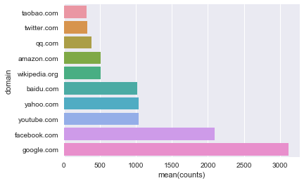

```python
# Place your code here
domains = c.groupby(['domain']).size().reset_index(name='counts')
domains = domains.sort_values(by='counts')
sns.barplot(x='counts',y='domain',data=domains)
```

4. List all records for the user with user id 37. (hint: this can be done using 'grep')

```python
# Place your code here
c[c.userid==37]
```

|  | userid | timestamp | domain | action |
| --- | --- | --- | --- | --- |
| 2517 | 37 | 648061658 | google.com | 0 |
| 2992 | 37 | 642479972 | google.com | 2 |
| 3321 | 37 | 644493341 | facebook.com | 2 |
| 3731 | 37 | 654941318 | facebook.com | 1 |
| 4823 | 37 | 649979874 | baidu.com | 1 |
| 5133 | 37 | 653061949 | yahoo.com | 1 |
| 6080 | 37 | 655020469 | google.com | 3 |
| 6550 | 37 | 640878012 | amazon.com | 0 |
| 7721 | 37 | 659864136 | youtube.com | 1 |
| 8693 | 37 | 640361378 | yahoo.com | 1 |
| 8695 | 37 | 653862134 | facebook.com | 0 |
| 8965 | 37 | 648828970 | youtube.com | 0 |

### Part 3: Dealing with data Pythonically

```python
# You might find these packages useful. You may import any others you want!
import pandas as pd
import numpy as np
```

1. Load the data set `"ads_dataset.tsv"` into a Python Pandas data frame called `ads`.

```python
# Place your code here
ads = DataFrame.from_csv('ads_dataset.tsv', sep='\t', header=0)
#t.describe()
ads.describe()
```

|  | isbuyer | buy_freq | visit_freq | buy_interval | sv_interval | expected_time_buy | expected_time_visit | last_buy | last_visit | multiple_buy | multiple_visit | uniq_urls | num_checkins | y_buy |
| --- | --- | --- | --- | --- | --- | --- | --- | --- | --- | --- | --- | --- | --- | --- |
| count | 54584.000000 | 2327.000000 | 54584.000000 | 54584.000000 | 54584.000000 | 54584.000000 | 54584.000000 | 54584.000000 | 54584.000000 | 54584.000000 | 54584.000000 | 54584.000000 | 54584.000000 | 54584.000000 |
| mean | 0.042632 | 1.240653 | 1.852777 | 0.210008 | 5.825610 | -0.198040 | -10.210786 | 64.729335 | 64.729335 | 0.006357 | 0.277444 | 86.569343 | 720.657592 | 0.004635 |
| std | 0.202027 | 0.782228 | 2.921820 | 3.922016 | 17.595442 | 4.997792 | 31.879722 | 53.476658 | 53.476658 | 0.079479 | 0.447742 | 61.969765 | 1275.727306 | 0.067924 |
| min | 0.000000 | 1.000000 | 0.000000 | 0.000000 | 0.000000 | -181.923800 | -187.615600 | 0.000000 | 0.000000 | 0.000000 | 0.000000 | -1.000000 | 1.000000 | 0.000000 |
| 25% | 0.000000 | 1.000000 | 1.000000 | 0.000000 | 0.000000 | 0.000000 | 0.000000 | 18.000000 | 18.000000 | 0.000000 | 0.000000 | 30.000000 | 127.000000 | 0.000000 |
| 50% | 0.000000 | 1.000000 | 1.000000 | 0.000000 | 0.000000 | 0.000000 | 0.000000 | 51.000000 | 51.000000 | 0.000000 | 0.000000 | 75.000000 | 319.000000 | 0.000000 |
| 75% | 0.000000 | 1.000000 | 2.000000 | 0.000000 | 0.104167 | 0.000000 | 0.000000 | 105.000000 | 105.000000 | 0.000000 | 1.000000 | 155.000000 | 802.000000 | 0.000000 |
| max | 1.000000 | 15.000000 | 84.000000 | 174.625000 | 184.916700 | 84.285710 | 91.401920 | 188.000000 | 188.000000 | 1.000000 | 1.000000 | 206.000000 | 37091.000000 | 1.000000 |

2. Write a Python function called `getDfSummary()` that does the following:

- Takes as input a data frame
- For each variable in the data frame calculates the following features:
  - `number_nan` to count the number of missing not-a-number values
  - Ignoring missing, NA, and Null values:
    - `number_distinct` to count the number of distinct values a variable can take on
    - `mean`, `max`, `min`, `std` (standard deviation), and `25%`, `50%`, `75%` to correspond to the appropriate percentiles
- All of these new features should be loaded in a new data frame. Each row of the data frame should be a variable from the input data frame, and the columns should be the new summary features.
- Returns this new data frame containing all of the summary information

Hint: The pandas `describe()` [(manual page)](http://pandas.pydata.org/pandas-docs/stable/generated/pandas.DataFrame.describe.html) method returns a useful series of values that can be used here.

```python
#Couldn't figure out how to smush these all together.
def getDfSummary(input_data):
    adict={}
    for column in input_data:
        #print(input_data[column].head())
        number_nan = input_data[column].isnull().sum()
        number_distinct = input_data[column].nunique()
        mean = input_data[column].mean()
        min = input_data[column].min()
        max = input_data[column].max()
        std = input_data[column].std()
        print(number_nan,number_distinct,mean,max,min,std)
        #print(number_nan)
```

3. How long does it take for your `getDfSummary()` function to work on your `ads` data frame? Show us the results below.

Hint: `%timeit getDfSummary(ads)`

```python
%timeit getDfSummary(ads)
```

[output not shown]

[output cut: 560 more lines]

4. Using the results returned from `getDfSummary()`, which fields, if any, contain missing `NaN` values?

```python
# Place your code here
miss = ads.isnull().sum()
miss

#Only the 'buy freq' variable has missing data
```

```
isbuyer                    0
buy_freq               52257
visit_freq                 0
buy_interval               0
sv_interval                0
expected_time_buy          0
expected_time_visit        0
last_buy                   0
last_visit                 0
multiple_buy               0
multiple_visit             0
uniq_urls                  0
num_checkins               0
y_buy                      0
dtype: int64
```

5. For the fields with missing values, does it look like the data is missing at random? Are there any other fields that correlate perfectly, or predict that the data is missing? If missing, what should the data value be?

Hint: create another data frame that has just the records with a missing value. Get a summary of this data frame using `getDfSummary()` and compare the differences. Do some feature distributions change dramatically?

```
1.0
             precision    recall  f1-score   support

      False       1.00      1.00      1.00       481
       True       1.00      1.00      1.00     10436

avg / total       1.00      1.00      1.00     10917

Index(['isbuyer', 'visit_freq', 'buy_interval', 'sv_interval',
       'expected_time_buy', 'expected_time_visit', 'last_buy', 'last_visit',
       'multiple_buy', 'multiple_visit', 'uniq_urls', 'num_checkins', 'y_buy'],
      dtype='object')
penalty :  l2
dual :  False
tol :  0.0001
C :  1.0
fit_intercept :  True
intercept_scaling :  1
class_weight :  None
random_state :  None
solver :  liblinear
max_iter :  100
multi_class :  ovr
verbose :  0
warm_start :  False
n_jobs :  1
classes_ :  [False  True]
coef_ :  [[ -1.01992510e+01  -1.87643607e-02  -3.15813329e-01   1.93423896e-03
    2.30047045e-01   8.85885634e-03   5.15267727e-03   5.15267727e-03
   -6.45064411e-02  -1.17119588e-01   3.51775439e-03   9.19487050e-06
   -1.33993596e-01]]
intercept_ :  [ 5.95725078]
n_iter_ :  [68]
```

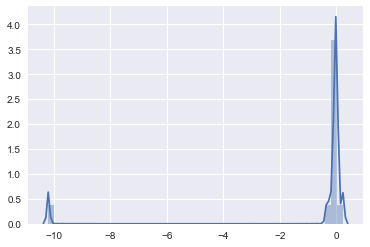

```python
# Place your code here
ads = DataFrame.from_csv('ads_dataset.tsv', sep='\t', header=0)
#Create a new dummy variable to flag missing 'missbuy'
ads['missbuy'] = pd.isnull(ads).any(axis=1)
ads = ads.drop('buy_freq',axis=1)

#drop the correlate of 'missbuy'
#ads = ads.drop('isbuyer',axis=1)

#imports
from sklearn.metrics import classification_report
from sklearn.linear_model import LogisticRegression
from sklearn.cross_validation import train_test_split
from sklearn import metrics
from sklearn.cross_validation import cross_val_score


#training/testing
X = ads.iloc[:,:-1]
y = ads.iloc[:,-1:]
X_train, X_test, y_train, y_test = train_test_split(X, y, test_size=0.2)
# %precision %5g

#model
model = LogisticRegression()
model = model.fit(X_train,y_train)
print(model.score(X_test,y_test))

y_pred = model.predict(X_test)


print(classification_report(y_test,y_pred))


print(X_train.columns)

for property, value in vars(model).items():
    print(property, ": ", value)
sns.distplot(model.coef_)



# The field 'isbuyer' seems to be quite related to the missingness of 'buyfreq'.
# This makes sense, as the 'buyfreq' variable was likely generated off of purchase
# history, something that would not be present if the customer was not 'isbuyer'.
# Including this field in a simple logistic regression model yields perfect results - not good!
# Dropping the 'isbuyer' variable results in much more realistic model performance.
```

6. Which variables are binary?

```python
# Place your code here
bool_cols = [col for col in ads if
               ads[col].dropna().value_counts().index.isin([0,1]).all()]
bool_cols
```

```
['isbuyer', 'multiple_buy', 'multiple_visit', 'y_buy', 'missbuy']
```